# Reproducible Research: Peer Assessment 1

## Loading and preprocessing the data

Loading Data from zip file.

```r
activity_data <- read.table(unz("./activity.zip", "activity.csv"), header=T, sep=",", colClasses = c("integer","Date", "integer"))
head(activity_data)
```

```
##   steps       date interval
## 1    NA 2012-10-01        0
## 2    NA 2012-10-01        5
## 3    NA 2012-10-01       10
## 4    NA 2012-10-01       15
## 5    NA 2012-10-01       20
## 6    NA 2012-10-01       25
```

## What is mean total number of steps taken per day?

Caclculating Total number of steps taken per day.

```r
steps_per_day <- tapply(activity_data$steps, activity_data$date, sum)
steps_per_day
```

```
## 2012-10-01 2012-10-02 2012-10-03 2012-10-04 2012-10-05 2012-10-06 2012-10-07
##         NA        126      11352      12116      13294      15420      11015
## 2012-10-08 2012-10-09 2012-10-10 2012-10-11 2012-10-12 2012-10-13 2012-10-14
##         NA      12811       9900      10304      17382      12426      15098
## 2012-10-15 2012-10-16 2012-10-17 2012-10-18 2012-10-19 2012-10-20 2012-10-21
##      10139      15084      13452      10056      11829      10395       8821
## 2012-10-22 2012-10-23 2012-10-24 2012-10-25 2012-10-26 2012-10-27 2012-10-28
##      13460       8918       8355       2492       6778      10119      11458
## 2012-10-29 2012-10-30 2012-10-31 2012-11-01 2012-11-02 2012-11-03 2012-11-04
##       5018       9819      15414         NA      10600      10571         NA
## 2012-11-05 2012-11-06 2012-11-07 2012-11-08 2012-11-09 2012-11-10 2012-11-11
##      10439       8334      12883       3219         NA         NA      12608
## 2012-11-12 2012-11-13 2012-11-14 2012-11-15 2012-11-16 2012-11-17 2012-11-18
##      10765       7336         NA         41       5441      14339      15110
## 2012-11-19 2012-11-20 2012-11-21 2012-11-22 2012-11-23 2012-11-24 2012-11-25
##       8841       4472      12787      20427      21194      14478      11834
## 2012-11-26 2012-11-27 2012-11-28 2012-11-29 2012-11-30
##      11162      13646      10183       7047         NA
```

Removing Days having steps ‘Not Available’.

```r
steps_per_day <- steps_per_day[!is.na(steps_per_day)]
steps_per_day
```

```
## 2012-10-02 2012-10-03 2012-10-04 2012-10-05 2012-10-06 2012-10-07 2012-10-09
##        126      11352      12116      13294      15420      11015      12811
## 2012-10-10 2012-10-11 2012-10-12 2012-10-13 2012-10-14 2012-10-15 2012-10-16
##       9900      10304      17382      12426      15098      10139      15084
## 2012-10-17 2012-10-18 2012-10-19 2012-10-20 2012-10-21 2012-10-22 2012-10-23
##      13452      10056      11829      10395       8821      13460       8918
## 2012-10-24 2012-10-25 2012-10-26 2012-10-27 2012-10-28 2012-10-29 2012-10-30
##       8355       2492       6778      10119      11458       5018       9819
## 2012-10-31 2012-11-02 2012-11-03 2012-11-05 2012-11-06 2012-11-07 2012-11-08
##      15414      10600      10571      10439       8334      12883       3219
## 2012-11-11 2012-11-12 2012-11-13 2012-11-15 2012-11-16 2012-11-17 2012-11-18
##      12608      10765       7336         41       5441      14339      15110
## 2012-11-19 2012-11-20 2012-11-21 2012-11-22 2012-11-23 2012-11-24 2012-11-25
##       8841       4472      12787      20427      21194      14478      11834
## 2012-11-26 2012-11-27 2012-11-28 2012-11-29
##      11162      13646      10183       7047
```

Converting to DataFrame.

```r
steps_per_day_df <- data.frame(Day=names(steps_per_day), Steps=steps_per_day, row.names=NULL)
head(steps_per_day_df)
```

```
##          Day Steps
## 1 2012-10-02   126
## 2 2012-10-03 11352
## 3 2012-10-04 12116
## 4 2012-10-05 13294
## 5 2012-10-06 15420
## 6 2012-10-07 11015
```

Plotting Histogram.

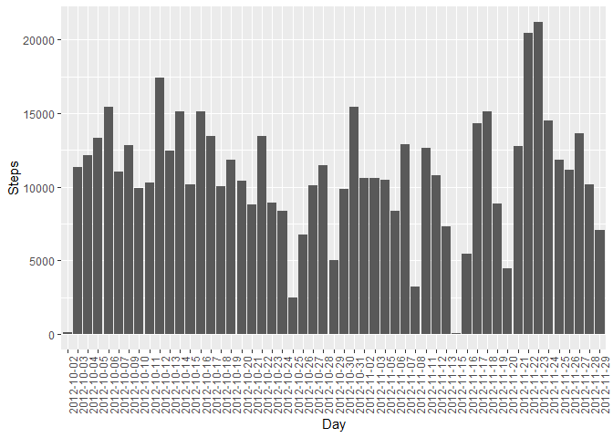

```r
library(ggplot2)
ggplot(steps_per_day_df, aes(x = Steps, y = Day)) +
       geom_histogram(stat = 'identity') + coord_flip() + theme(axis.text.x = element_text(angle = 90))
```

Mean of the total nuumber of steps taken per day.

```r
mean(steps_per_day)
```

```
## [1] 10766.19
```

Median of the total number of steps taken per day.

```r
median(steps_per_day)
```

```
## [1] 10765
```

## What is the average daily activity pattern?

Calculating Average across all days for each interval.

```r
avg_per_interval <- tapply(activity_data$steps, activity_data$interval, mean, na.rm=TRUE)
avg_per_interval
```

```
##           0           5          10          15          20          25
##   1.7169811   0.3396226   0.1320755   0.1509434   0.0754717   2.0943396
##          30          35          40          45          50          55
##   0.5283019   0.8679245   0.0000000   1.4716981   0.3018868   0.1320755
##         100         105         110         115         120         125
##   0.3207547   0.6792453   0.1509434   0.3396226   0.0000000   1.1132075
##         130         135         140         145         150         155
##   1.8301887   0.1698113   0.1698113   0.3773585   0.2641509   0.0000000
##         200         205         210         215         220         225
##   0.0000000   0.0000000   1.1320755   0.0000000   0.0000000   0.1320755
##         230         235         240         245         250         255
##   0.0000000   0.2264151   0.0000000   0.0000000   1.5471698   0.9433962
##         300         305         310         315         320         325
##   0.0000000   0.0000000   0.0000000   0.0000000   0.2075472   0.6226415
##         330         335         340         345         350         355
##   1.6226415   0.5849057   0.4905660   0.0754717   0.0000000   0.0000000
##         400         405         410         415         420         425
##   1.1886792   0.9433962   2.5660377   0.0000000   0.3396226   0.3584906
##         430         435         440         445         450         455
##   4.1132075   0.6603774   3.4905660   0.8301887   3.1132075   1.1132075
##         500         505         510         515         520         525
##   0.0000000   1.5660377   3.0000000   2.2452830   3.3207547   2.9622642
##         530         535         540         545         550         555
##   2.0943396   6.0566038  16.0188679  18.3396226  39.4528302  44.4905660
##         600         605         610         615         620         625
##  31.4905660  49.2641509  53.7735849  63.4528302  49.9622642  47.0754717
##         630         635         640         645         650         655
##  52.1509434  39.3396226  44.0188679  44.1698113  37.3584906  49.0377358
##         700         705         710         715         720         725
##  43.8113208  44.3773585  50.5094340  54.5094340  49.9245283  50.9811321
##         730         735         740         745         750         755
##  55.6792453  44.3207547  52.2641509  69.5471698  57.8490566  56.1509434
##         800         805         810         815         820         825
##  73.3773585  68.2075472 129.4339623 157.5283019 171.1509434 155.3962264
##         830         835         840         845         850         855
## 177.3018868 206.1698113 195.9245283 179.5660377 183.3962264 167.0188679
##         900         905         910         915         920         925
## 143.4528302 124.0377358 109.1132075 108.1132075 103.7169811  95.9622642
##         930         935         940         945         950         955
##  66.2075472  45.2264151  24.7924528  38.7547170  34.9811321  21.0566038
```

[output cut: 41 more lines]

```
##  19.6226415  19.0188679  19.3396226  33.3396226  26.8113208  21.1698113
##        2030        2035        2040        2045        2050        2055
##  27.3018868  21.3396226  19.5471698  21.3207547  32.3018868  20.1509434
##        2100        2105        2110        2115        2120        2125
##  15.9433962  17.2264151  23.4528302  19.2452830  12.4528302   8.0188679
##        2130        2135        2140        2145        2150        2155
##  14.6603774  16.3018868   8.6792453   7.7924528   8.1320755   2.6226415
##        2200        2205        2210        2215        2220        2225
##   1.4528302   3.6792453   4.8113208   8.5094340   7.0754717   8.6981132
##        2230        2235        2240        2245        2250        2255
##   9.7547170   2.2075472   0.3207547   0.1132075   1.6037736   4.6037736
##        2300        2305        2310        2315        2320        2325
##   3.3018868   2.8490566   0.0000000   0.8301887   0.9622642   1.5849057
##        2330        2335        2340        2345        2350        2355
##   2.6037736   4.6981132   3.3018868   0.6415094   0.2264151   1.0754717
```

Converting to DataFrame.

```r
avg_per_interval_df <- data.frame(Interval=as.numeric(names(avg_per_interval)), Steps=avg_per_interval, row.names=NULL)
head(avg_per_interval_df)
```

```
##   Interval     Steps
## 1        0 1.7169811
## 2        5 0.3396226
## 3       10 0.1320755
## 4       15 0.1509434
## 5       20 0.0754717
## 6       25 2.0943396
```

Time Series Plot.

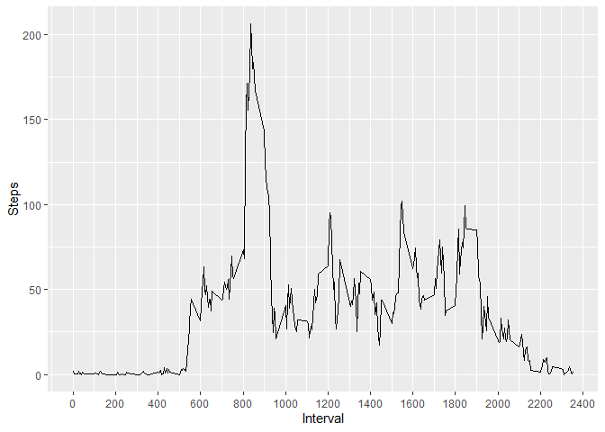

```r
ggplot(avg_per_interval_df, aes(x=Interval, y=Steps, group=1)) + geom_line() + scale_x_continuous(breaks=seq(-200,2400, 200))
```

Interval With maximum number of steps.

```r
avg_per_interval_df[which.max(avg_per_interval_df$Steps),]
```

```
##     Interval    Steps
## 104      835 206.1698
```

## Imputing missing values

Total number of missing values in the dataset.

```r
nrow(activity_data[is.na(activity_data$steps), ])
```

```
## [1] 2304
```

Creating new dataset by filling missing values in original dataset. Missing Values will be filled by mean of steps with respect to interval (calculated above).

```r
activity_data_filled = activity_data

na_indices <- which(is.na(activity_data$steps))

for (index in na_indices) {

    curr_interval <- activity_data[index,]$interval

    avg_steps <- avg_per_interval_df[avg_per_interval_df$Interval == curr_interval,]$Steps

    activity_data_filled[index,]$steps <- avg_steps
}

head(activity_data_filled)
```

```
##       steps       date interval
## 1 1.7169811 2012-10-01        0
## 2 0.3396226 2012-10-01        5
## 3 0.1320755 2012-10-01       10
## 4 0.1509434 2012-10-01       15
## 5 0.0754717 2012-10-01       20
## 6 2.0943396 2012-10-01       25
```

Caclculating Total number of steps taken per day after filling missing values.

```r
steps_per_day_filled <- tapply(activity_data_filled$steps, activity_data_filled$date, sum)
steps_per_day_filled
```

```
## 2012-10-01 2012-10-02 2012-10-03 2012-10-04 2012-10-05 2012-10-06 2012-10-07
##   10766.19     126.00   11352.00   12116.00   13294.00   15420.00   11015.00
## 2012-10-08 2012-10-09 2012-10-10 2012-10-11 2012-10-12 2012-10-13 2012-10-14
##   10766.19   12811.00    9900.00   10304.00   17382.00   12426.00   15098.00
## 2012-10-15 2012-10-16 2012-10-17 2012-10-18 2012-10-19 2012-10-20 2012-10-21
##   10139.00   15084.00   13452.00   10056.00   11829.00   10395.00    8821.00
## 2012-10-22 2012-10-23 2012-10-24 2012-10-25 2012-10-26 2012-10-27 2012-10-28
##   13460.00    8918.00    8355.00    2492.00    6778.00   10119.00   11458.00
## 2012-10-29 2012-10-30 2012-10-31 2012-11-01 2012-11-02 2012-11-03 2012-11-04
##    5018.00    9819.00   15414.00   10766.19   10600.00   10571.00   10766.19
## 2012-11-05 2012-11-06 2012-11-07 2012-11-08 2012-11-09 2012-11-10 2012-11-11
##   10439.00    8334.00   12883.00    3219.00   10766.19   10766.19   12608.00
## 2012-11-12 2012-11-13 2012-11-14 2012-11-15 2012-11-16 2012-11-17 2012-11-18
##   10765.00    7336.00   10766.19      41.00    5441.00   14339.00   15110.00
## 2012-11-19 2012-11-20 2012-11-21 2012-11-22 2012-11-23 2012-11-24 2012-11-25
##    8841.00    4472.00   12787.00   20427.00   21194.00   14478.00   11834.00
## 2012-11-26 2012-11-27 2012-11-28 2012-11-29 2012-11-30
##   11162.00   13646.00   10183.00    7047.00   10766.19
```

Converting to DataFrame.

```r
steps_per_day_filled_df <- data.frame(Day=names(steps_per_day_filled), Steps=steps_per_day_filled, row.names=NULL)
head(steps_per_day_filled_df)
```

```
##          Day    Steps
## 1 2012-10-01 10766.19
## 2 2012-10-02   126.00
## 3 2012-10-03 11352.00
## 4 2012-10-04 12116.00
## 5 2012-10-05 13294.00
## 6 2012-10-06 15420.00
```

Plotting Histogram.

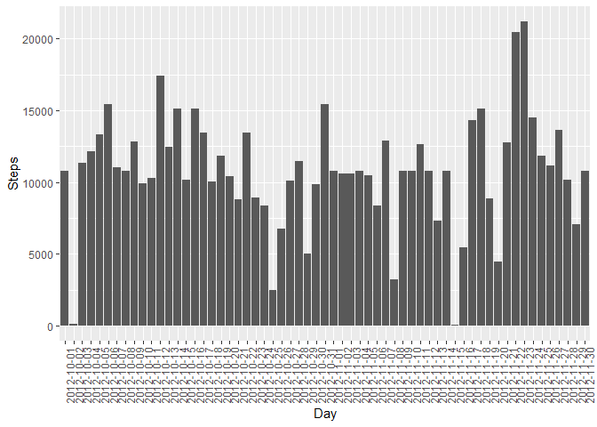

```r
library(ggplot2)
ggplot(steps_per_day_filled_df, aes(x = Steps, y = Day)) +
       geom_histogram(stat = 'identity') + coord_flip() + theme(axis.text.x = element_text(angle = 90))
```

Mean of the total nuumber of steps taken per day.

```r
mean(steps_per_day_filled)
```

```
## [1] 10766.19
```

Median of the total number of steps taken per day.

```r
median(steps_per_day_filled)
```

```
## [1] 10766.19
```

After imputing missing values mean and median values of the Total Steps per day became equal.

## Are there differences in activity patterns between weekdays and weekends?

Creating a new variable to indicate whether given day is weekend or weekday

```r
library(chron)
daytype <- is.weekend(activity_data_filled$date)
activity_data_filled$daytype <- factor(ifelse(daytype, "weekend", "weekday"))
head(activity_data_filled)
```

```
##       steps       date interval daytype
## 1 1.7169811 2012-10-01        0 weekday
## 2 0.3396226 2012-10-01        5 weekday
## 3 0.1320755 2012-10-01       10 weekday
## 4 0.1509434 2012-10-01       15 weekday
## 5 0.0754717 2012-10-01       20 weekday
## 6 2.0943396 2012-10-01       25 weekday
```

Calculating Average across all weekdays and weekends for each interval.

```r
library(reshape)
avg_per_interval_daytype <- tapply(activity_data_filled$steps, list(activity_data_filled$interval, activity_data_filled$daytype), mean)
avg_per_interval_daytype_df <- as.data.frame(avg_per_interval_daytype)
avg_per_interval_daytype_df$interval <- row.names(avg_per_interval_daytype_df)
avg_per_interval_daytype_df <- melt.data.frame(avg_per_interval_daytype_df)
colnames(avg_per_interval_daytype_df) <- c("interval", "daytype", "steps")
head(avg_per_interval_daytype_df)
```

```
##   interval daytype      steps
## 1        0 weekday 2.25115304
## 2        5 weekday 0.44528302
## 3       10 weekday 0.17316562
## 4       15 weekday 0.19790356
## 5       20 weekday 0.09895178
## 6       25 weekday 1.59035639
```

Plotting Time Series graph with respect to day type.

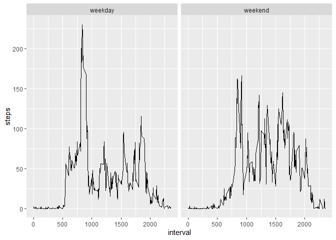

```r
ggplot(avg_per_interval_daytype_df, aes(x=as.numeric(interval), y=steps, group=1)) + geom_line() + facet_grid(. ~ daytype, scales="free") + xlab("interval")
```